# Biodiversity EDA — Peter (Individual)

Yudian (Peter) Pan

January 20, 2026

# Introduction

This individual report provides an exploratory analysis of biodiversity-related features within **The Beach BIA** area. The analysis uses iNaturalist observations together with spatial layers (tree inventory, greenspaces, and waterbodies) to (i) identify **where** observations are concentrated and (ii) summarize **how** observation volume varies across time and across spatial units (Beach BIA vs Woodbine Beach vs the broader AOI).

To keep this deliverable consistent with our group work, the data pipeline and spatial definitions reuse the same consolidated workflow (AOI union + buffer, consistent CRS handling, and the same iNaturalist classification rules). This document is written in a **report-style HTML format** (text + figure, minimal console noise) so it can be submitted as a standalone artifact.

# Research objectives

This EDA focuses on two questions:

1. **iNaturalist patterns:** Are there identifiable spatial and temporal patterns in the number of observations inside the AOI?
2. **Tree density:** How does tree density vary across the Beach BIA commercial strip relative to nearby areas?

# Data description

This EDA uses four datasets:

- **iNaturalist observations (CSV):** user-reported wildlife observations with geographic coordinates and observation dates. Observations are filtered to the AOI and deduplicated by observation ID when available.
- **Tree inventory (vector layer):** point locations of trees from Toronto Open Data.
- **Greenspaces (vector layer):** polygon boundaries of designated greenspaces.
- **Waterbodies (vector layer):** polygon boundaries of water features.

# Methods and data preparation

## Area of interest (AOI)

The AOI is constructed as the **union** of: (i) the Beach BIA polygon, (ii) the Woodbine Beach polygon, and (iii) (when available) the broader “The Beaches” neighbourhood polygon, followed by a **buffer of 30 meters** to capture nearby observations at the boundary. All spatial operations are performed in a projected CRS for buffering/union, then returned to EPSG:4326 for mapping.

## Cleaning and classification

- iNaturalist points are converted to an `sf` point object and filtered to valid latitude/longitude.
- Observations are assigned to broad categories using the iconic taxon field (Plants, Birds, Insects, Mammals, Reptiles, Spiders, Other).
- For reproducibility and convenient reuse, intermediate objects are cached to GeoJSON under `Results/Biodiversity_Peter/`.

## Snapshot summary

Within the AOI (union + buffer), the filtered dataset contains **10450 observations** and **1577 unique species**, over an area of **431.54 hectares**. The tree inventory contributes **9137 tree points** in the same AOI.

Table 1. Summary statistics for the AOI used in the biodiversity EDA.

| total_obs | unique_species | tree_points | area_ha | species_per_ha | aoi_buffer_m |
| --- | --- | --- | --- | --- | --- |
| 10450 | 1577 | 9137 | 431.54 | 3.654 | 30 |

# Exploratory data analysis

## Question 1 — Spatial and temporal patterns in iNaturalist observations

### Fig 1. Spatial distribution of observations and trees

The map below overlays iNaturalist observations (grouped by broad category) and tree points within the AOI. Visual clustering near greenspaces and the lakeshore suggests that biodiversity observations are not uniformly distributed across the district; instead, they tend to concentrate around natural corridors and park-like areas.

[interactive chart not shown]

### Fig 2. Composition of observations by broad category

The figure below summarizes the distribution of observations across broad categories. Because iNaturalist is user-driven, this composition reflects both ecological presence and observer behavior (e.g., which taxa are easier to detect and report).

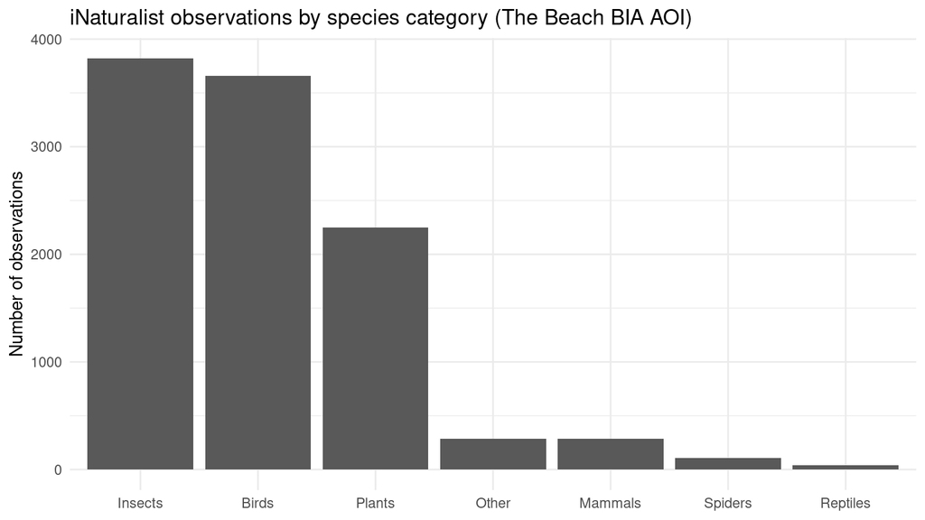

Figure 2. Observation counts by broad iNaturalist category inside the AOI.

### Fig 3. Annual observation trend since 2020

Aggregating by year provides a simple view of temporal variation. In practice, changes over time can reflect both ecological variation and shifts in participation (more users, more reporting, or targeted observation events).

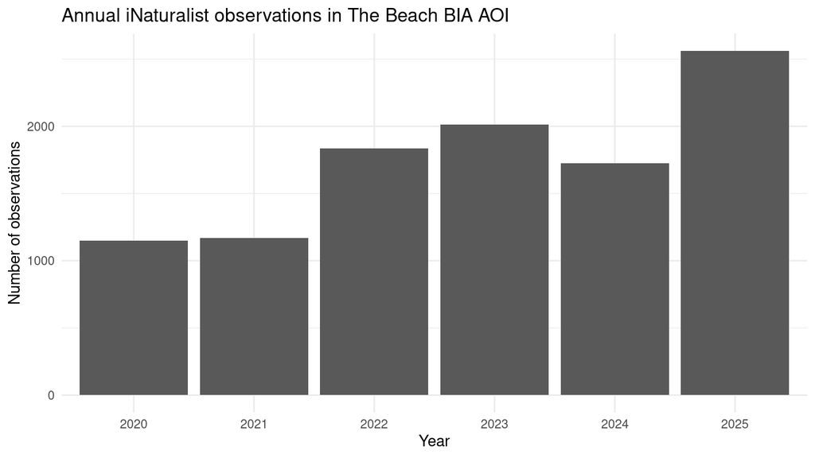

Figure 3. Annual observation counts within the AOI (2020 to present).

## Question 2 — Tree density along the commercial strip

To complement the spatial maps, we compute a simple density metric: **trees per km^2**, using each unit’s area and the number of tree points that fall inside it.

Table 2. Tree density summary (trees per km^2) across spatial units.

| area | tree_points | area_ha | trees_per_km2 |
| --- | --- | --- | --- |
| AOI buffer (union) | 9137 | 431.54 | 2117.301 |
| Beach BIA | 608 | 40.47 | 1502.347 |
| Woodbine Beach | 568 | 90.46 | 627.902 |

In Table 2, the Beach BIA density is approximately **1502 trees per km^2**, compared with **628 trees per km^2** in Woodbine Beach and **2117 trees per km^2** at the AOI level. These summaries are sensitive to how each polygon is defined (area) and how tree points are recorded, so they should be interpreted as *comparative* rather than absolute measures.

### Fig 4. Tree density heatmap inside the Beach BIA

The interactive heatmap emphasizes where tree points are most concentrated inside the Beach BIA polygon. This provides a visual complement to Table 2 by highlighting local clustering rather than a single area-average value.

[interactive chart not shown]

# Discussion and next steps

This EDA suggests that biodiversity-related activity (as proxied by iNaturalist observations) is spatially structured in the Beach BIA AOI: observations cluster around greenspaces and the lakeshore, while the commercial corridor appears comparatively sparse. Tree density patterns similarly show heterogeneity across space—area-level averages are informative, but the heatmap highlights localized concentration and potential gaps.

**Limitations and interpretation notes:**

- iNaturalist is **user-generated**: observation counts reflect both ecological presence and observer effort, and may over-represent easily observed or popular taxa.
- Spatial layers come from different sources and vintages; polygon boundaries and point inventories can shift with updates, which affects counts near borders.
- Buffers (AOI and near-water) are small by design; results may change if these thresholds are adjusted.

If this work is extended to a simple modelling step, two natural directions are:

- **Spatial intensity modelling:** treat observations as a point process intensity surface and compare intensity near greenspace/water vs farther away.
- **Count modelling across units:** aggregate observations to small grid cells or street segments and model counts using predictors such as distance-to-water, greenspace proportion, and tree density.

# Appendix

**Click to expand: additional exploration and saved outputs**

### A1. Monthly trend (optional)

This figure refines Fig 3 by showing within-year seasonality. Peaks likely reflect both ecological seasonality and reporting intensity.

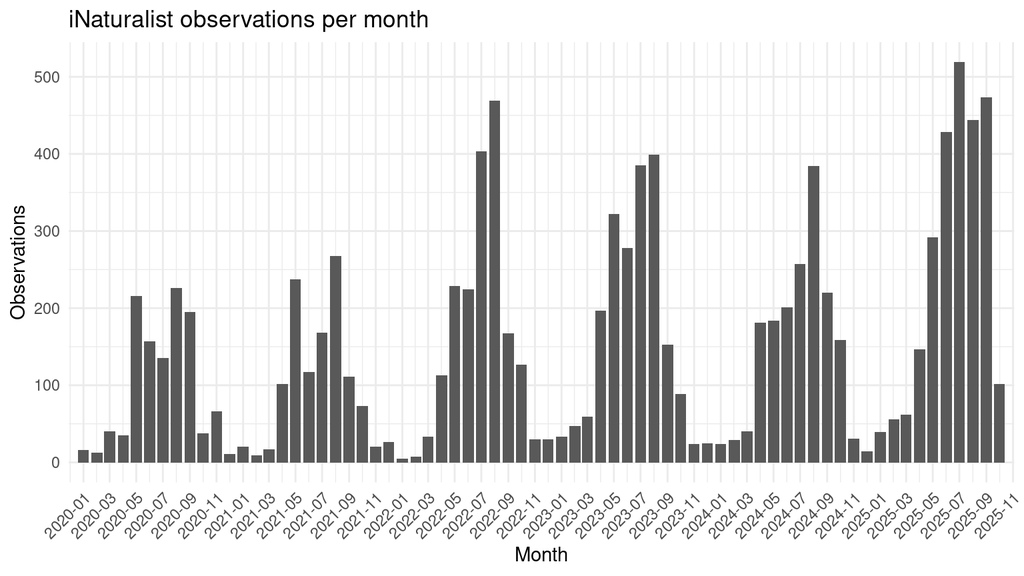

### A2. Neighbourhood richness choropleth (within AOI)

This map compares neighbourhood-level richness (unique species) within the AOI. It helps identify which surrounding neighbourhoods may be driving the AOI-level totals.

[interactive chart not shown]

### A3. Near-water analysis

This table checks whether observations are disproportionately near water. It supports the narrative that lakeshore proximity is associated with higher observation activity.

Near-water share across all categories.

| overall_share_near |
| --- |
| 0.165 |

Near-water share by category.

| category | near | away | share_near |
| --- | --- | --- | --- |
| Birds | 832 | 2828 | 0.227 |
| Insects | 352 | 3467 | 0.092 |
| Mammals | 56 | 228 | 0.197 |
| Other | 109 | 179 | 0.378 |
| Plants | 333 | 1918 | 0.148 |
| Reptiles | 23 | 17 | 0.575 |
| Spiders | 16 | 92 | 0.148 |

### A4. Top-10 species layered map

This interactive map shows where the most frequently reported species occur. It is included for interpretability and to support follow-up modelling choices (e.g., species-specific patterns).

[interactive chart not shown]

### A5. Per-year layered map

This map visualizes whether the spatial footprint of observations changes by year. It complements Fig 3 by showing whether increases are broad-based or localized.

[interactive chart not shown]

### A6. Top-5 species by area (tables)

These tables summarize the dominant species within each spatial unit. They help interpret differences in richness and composition across areas.

Top 5 species by observation count within each spatial unit.

| area | scientific_name | n |
| --- | --- | --- |
| Beach BIA | Danaus plexippus | 22 |
| Beach BIA | Harmonia axyridis | 13 |
| Beach BIA | Vanessa atalanta | 13 |
| Beach BIA | Passer domesticus | 10 |
| Beach BIA | Petasites japonicus | 10 |
| Woodbine Beach | Danaus plexippus | 52 |
| Woodbine Beach | Larus delawarensis | 46 |
| Woodbine Beach | Agelaius phoeniceus | 45 |
| Woodbine Beach | Charadrius vociferus | 40 |
| Woodbine Beach | Pantala hymenaea | 31 |
| AOI buffer (union) | Danaus plexippus | 167 |
| AOI buffer (union) | Turdus migratorius | 94 |
| AOI buffer (union) | Larus delawarensis | 90 |
| AOI buffer (union) | Charadrius vociferus | 89 |
| AOI buffer (union) | Agelaius phoeniceus | 88 |

### A7. Mini data dictionary

This dictionary documents exported outputs for reproducibility and grading transparency.

Outputs data dictionary.

| file | column | meaning |
| --- | --- | --- |
| bio_summary_final.csv | total_obs | iNat observations inside AOI |
| bio_summary_final.csv | unique_species | distinct scientific_name |
| bio_summary_final.csv | tree_points | tree records inside AOI |
| bio_summary_final.csv | area_ha | AOI area (hectares) |
| bio_summary_final.csv | species_per_ha | unique_species / area_ha |
| bio_summary_final.csv | aoi_buffer_m | AOI buffer distance (meters) |
| neighbourhood_biodiversity_summary.csv | neigh | neighbourhood name |
| neighbourhood_biodiversity_summary.csv | unique_species | species within neighbourhood AOI |
| neighbourhood_biodiversity_summary.csv | area_ha | neighbourhood area in AOI (ha) |
| neighbourhood_biodiversity_summary.csv | species_per_ha | unique_species / area_ha |
| near_water_by_category.csv | share_near | near / (near + away) |
| tree_density_by_area.csv | trees_per_km2 | tree_points / area_km2 |